# Homework № 2

Abishev Daur

## Задание 1

Используем набор данных из файла «задание1.xlsx». Файл не содержит пустых значений:

```r
df <- read_excel('задание1.xlsx')

sum(is.na(df))
```

```
## [1] 0
```

Метод главных компонент для понижения размерности данных о результативности деятельности российских вузов:

```r
pca <- prcomp(df[,-c(1)], center = TRUE, scale = TRUE)
summary(pca)
```

```
## Importance of components:
##                           PC1    PC2     PC3     PC4     PC5     PC6     PC7
## Standard deviation     2.4059 1.4092 1.14417 0.96359 0.94776 0.82369 0.74918
## Proportion of Variance 0.4134 0.1419 0.09351 0.06632 0.06416 0.04846 0.04009
## Cumulative Proportion  0.4134 0.5553 0.64880 0.71513 0.77929 0.82775 0.86784
##                            PC8     PC9    PC10    PC11    PC12   PC13    PC14
## Standard deviation     0.72619 0.69719 0.56762 0.53358 0.35872 0.2592 0.18459
## Proportion of Variance 0.03767 0.03472 0.02301 0.02034 0.00919 0.0048 0.00243
## Cumulative Proportion  0.90551 0.94023 0.96324 0.98358 0.99277 0.9976 1.00000
```

Как видно из результатов для сохранения 75% первоначальной информации нам достаточно использовать первые пять компонент. Они будут давать 0.779 информации.

```r
pca$sdev
```

```
##  [1] 2.4058593 1.4092406 1.1441746 0.9635919 0.9477594 0.8236885 0.7491808
##  [8] 0.7261863 0.6971889 0.5676183 0.5335758 0.3587176 0.2592116 0.1845883
```

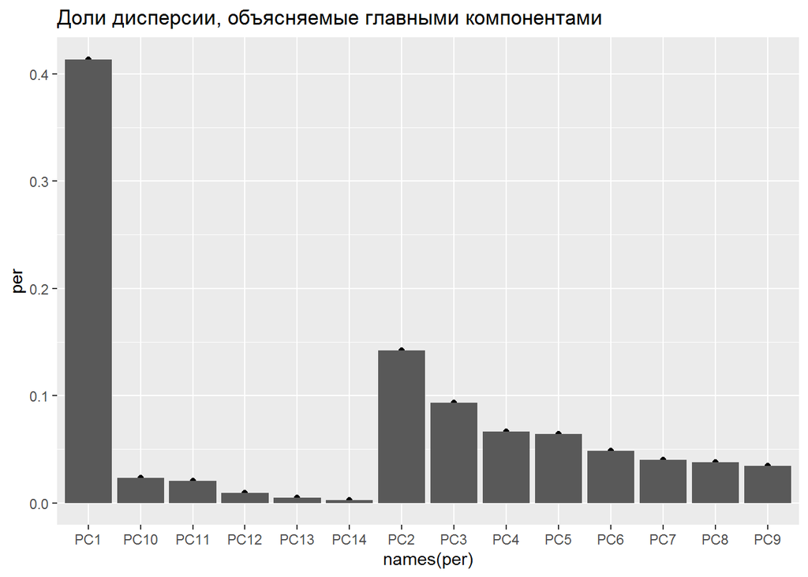

```r
per <- summary(pca)$importance[2,]
qplot(y = per, x = names(per)) +
  geom_bar(stat = 'identity') +
  labs(title = "Доли дисперсии, объясняемые главными компонентами")
```

## Задание 2

Задана случайная величина 𝑋, распределение которой неизвестно. Из данной случайной величины была получена выборка 𝑥 = {3,5,7,9,9,10,11,13,17,19}.

```r
x <- c(3,5,7,9,9,10,11,13,17,19)
h <-  0.25
n <-  length(x)
```

Найдем оценки 𝑓(𝑥) в точках 5 и 10, используя: a) Ядро Епанечникова.

Для точки 5:

```r
s_5 = 0
for (i in 1:n){
  x_5 = (x[i] - 5) / h
  s_5 = s_5 + 3/4 * max(1-x_5^2, 0)
}
s_5 = s_5 / (n*h)
s_5
```

```
## [1] 0.3
```

Для точки 10:

```r
s_10 = 0
for (i in 1:n){
  x_10 = (x[i] - 10) / h
  s_10 = s_10 + 3/4 * max(1-x_10^2, 0)
}
s_10 = s_10 / (n*h)
s_10
```

```
## [1] 0.3
```

Найдем оценки 𝑓(𝑥) в точках 5 и 10, используя: b) Гауссово ядро

Для точки 5:

```r
s_5 = 0
for (i in 1:n){
  x_5 = (x[i] - 5) / h
  s_5 = s_5 + 1/(sqrt(2) * pi) * exp(-x_5^2 /2)
}
s_5 = s_5 / (n*h)
s_5
```

```
## [1] 0.09003163
```

Для точки 10:

```r
s_10 = 0
for (i in 1:n){
  x_10 = (x[i] - 10) / h
  s_10 = s_10 + 1/(sqrt(2) * pi) * exp(-x_10^2 /2)
}
s_10 = s_10 / (n*h)
s_10
```

```
## [1] 0.09012224
```

## Задание 3

Используем набор данных «задание3.xlsx», содержащий основные характеристики социально-экономического развития регионов России.

```r
df <- read_excel('задание3.xlsx')
sum(is.na(df))
```

```
## [1] 1
```

Избавимся от пустого значения заменив его на среднее. Также заменим “,” на “.”:

```r
for ( i in 2:ncol(df)) {
  df[[i]] <- as.numeric(gsub(",", ".", df[[i]]) )
}

df$x13[is.na(df$x13)] <- mean(df$x13, na.rm = T)
sum(is.na(df))
```

```
## [1] 0
```

Выберtем 4 переменные, которые могут использоваться для классификации регионов. Это Площадь территории, тыс. км2, Численность населения, тыс. чел., ВРП, млн. руб., Объем добычи полезных ископаемых, млн. руб.:

```r
df_k <- df[,c(2,3,8,11)]
```

Найдем оптимальное количество кластеров, методом “Elbow”:

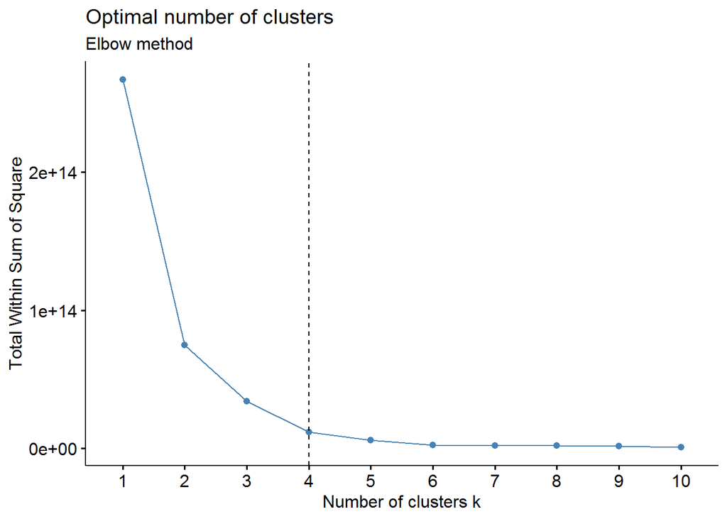

```r
fviz_nbclust(df_k, kmeans, method = "wss") +
  geom_vline(xintercept = 4, linetype = 2)+
  labs(subtitle = "Elbow method")
```

Как видно из графика оптимальное количество будет при 4 кластеров.

Осуществим классификацию методом к-средних при 4 кластеров:

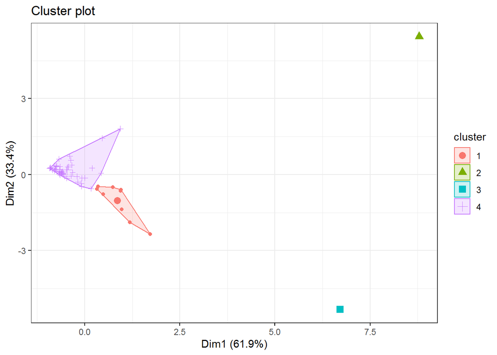

```r
km.out =kmeans (df_k, 4, nstart =20)

fviz_cluster(km.out, data = df_k,
             geom = "point",
             ellipse.type = "convex",
             ggtheme = theme_bw()
)
```

Реализуем алгоритм иерархической кластеризации:

```r
hc.complete =hclust (dist(df_k), method ="complete")
hc.average =hclust (dist(df_k), method ="average")
hc.single =hclust (dist(df_k), method ="single")
```

И построим дендограммы:

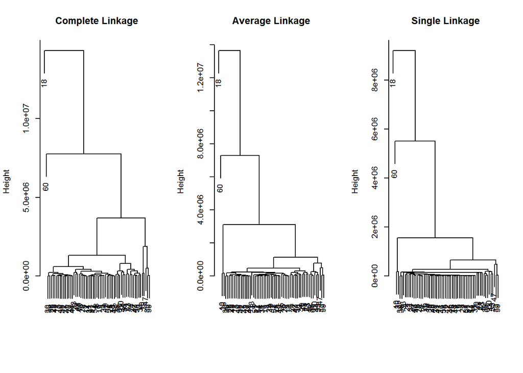

```r
par(mfrow =c(1,3))
plot(hc.complete ,main =" Complete Linkage ", xlab="", sub ="",cex =.9)
plot(hc.average , main =" Average Linkage ", xlab="", sub ="",cex =.9)
plot(hc.single , main=" Single Linkage ", xlab="", sub ="",cex =.9)
```

## Задание 4

Используйте набор данных «задание4.xlsx» и избавимся от пустого значения заменив его на среднее:

```r
df <- read_excel('задание4.xlsx')
df$x1[is.na(df$x1)] <- mean(df$x1, na.rm = T)
sum(is.na(df$x1))
```

```
## [1] 0
```

```r
bw1 <- sqrt(var(df$x1)) * length(df$x1) ^ (-1/5)
kde11<-density(df$x1,bw1,kernel="gaussian")
kde21<-density(df$x1,bw1,kernel="epanechnikov")
kde31<-density(df$x1,bw1,kernel="biweight")
```

Построим также графики:

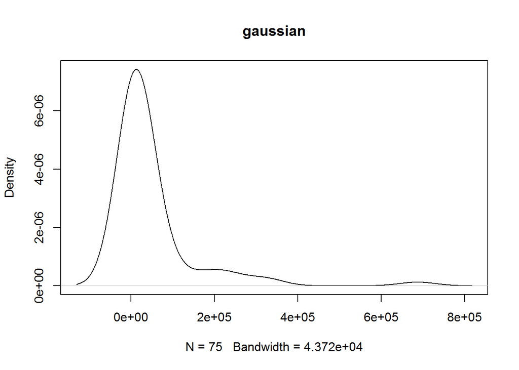

```r
plot(kde11, main= 'gaussian')
```

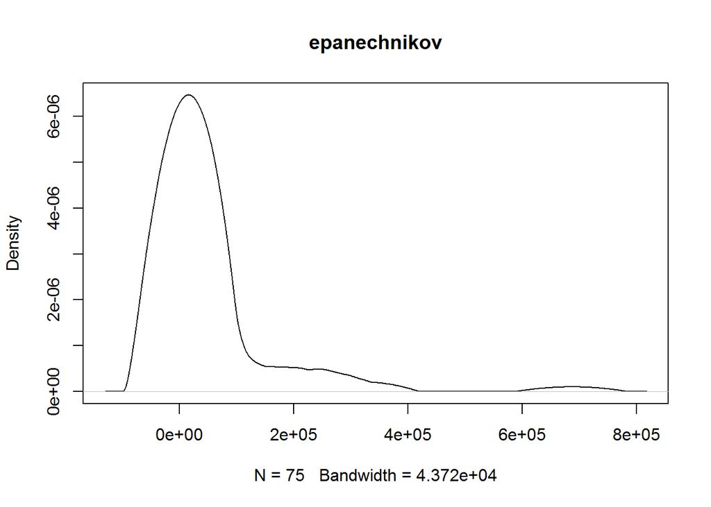

```r
plot(kde21, main= 'epanechnikov')
```

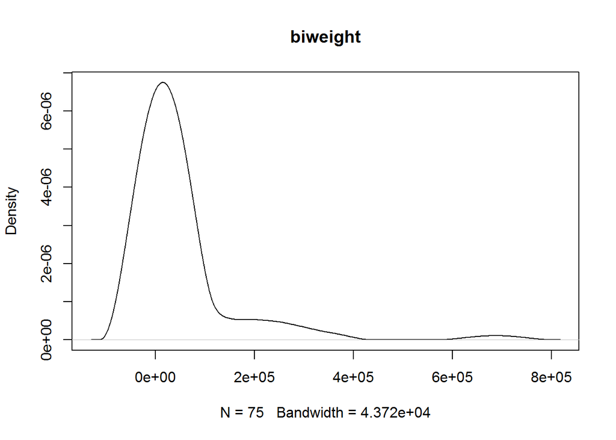

```r
plot(kde31, main= 'biweight')
```

```r
bw <- sqrt(var(df$x2)) * length(df$x2) ^ (-1/5)
kde1<-density(df$x2,bw,kernel="gaussian")
kde2<-density(df$x2,bw,kernel="epanechnikov")
kde3<-density(df$x2,bw,kernel="biweight")
```

Построим также графики:

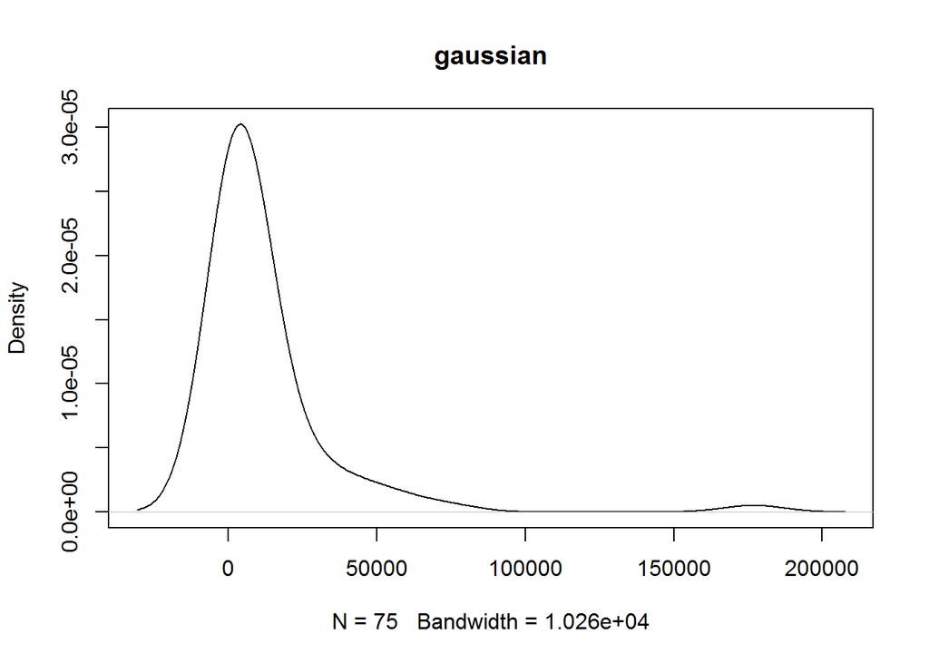

```r
plot(kde1, main= 'gaussian')
```

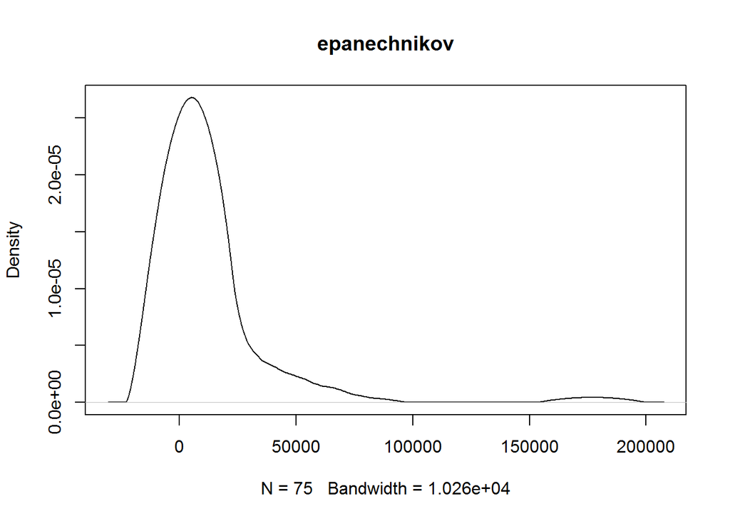

```r
plot(kde2, main= 'epanechnikov')
```

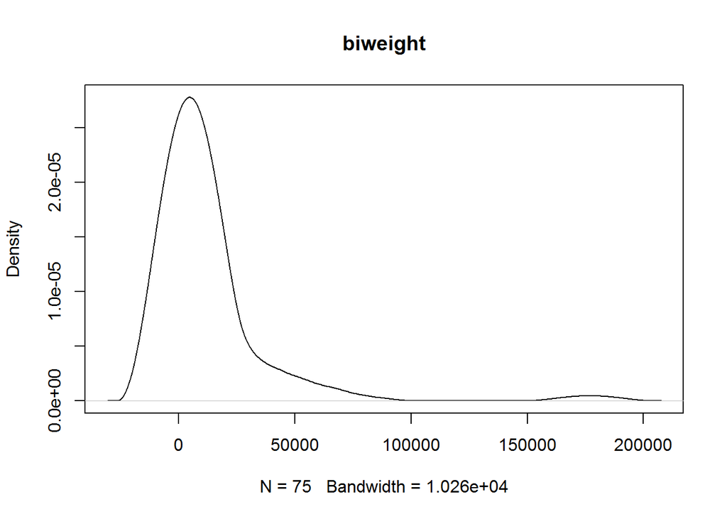

```r
plot(kde3, main= 'biweight')
```

## Задание 5

Используйте набор данных «Weekly» из пакета «ISLR»:

```r
df <-  Weekly
sum(is.na(df))
```

```
## [1] 0
```

```r
lda <- lda(Lag2 ~ ., data = df)
lda$scaling
```

```
##                     LD1         LD2         LD3         LD4         LD5
## Year         0.17569951  0.06502580 -0.08188302  0.08472260  0.03736561
## Lag1         0.10975428  0.05183137  0.23764041  0.21535828 -0.35843897
## Lag3         0.15515945 -0.53707164 -0.29145262 -0.03359121 -0.12835598
## Lag4         0.24856472 -0.34071052  0.42637540  0.06871489  0.13553523
## Lag5        -0.10948128 -0.03878008 -0.07162251  0.48552951  0.20410270
## Volume      -1.37307723 -0.53439196  0.36875096 -0.15870616 -0.20838594
## Today       -0.05916273 -0.05454269  0.06970650  0.18839984 -0.32528922
## DirectionUp -0.33460442 -0.41576875  0.61576330 -0.95149632  1.39991855
##                     LD6          LD7         LD8
## Year        -0.08044377 -0.006179558  0.23128899
## Lag1         0.19768824 -0.012757555  0.03115198
## Lag3         0.02638347  0.023062206 -0.01569474
## Lag4        -0.05679116 -0.093296394 -0.01742036
## Lag5         0.07456551  0.038983934 -0.07691306
## Volume       0.21387696 -0.143973748 -0.52328762
## Today       -0.50338570  0.190006516 -0.09481324
## DirectionUp  2.25898258  0.881274546  0.78938414
```

```r
lda$svd
```

```
## [1] 1.8543143 1.5695364 1.4833774 1.3619226 1.2093950 1.0679021 0.9026801
## [8] 0.8638420
```

```r
lda$N
```

```
## [1] 1089
```